# Southeast Asia Energy Consumption Visualization Project

Group 2

2026-07-13

## Team Introduction

**Group 2 Members:**  
1. Lim Ze Kai  
2. Ziven Wang  
3. Tan Jing Yu  
4. Ivan Tan  
5. Jaison Tan

## Project Overview

After initial general research across ASEAN countries, we narrowed down on energy visualizations as they are often poorly represented.

Our presentation documents a critique and improvement of an existing visualization of Southeast Asia’s energy consumption.

[figure not shown]

## Project Objectives

1. How does fuel consumption and their type vary across the different ASEAN nations?
2. Are there meaningful structural differences in how energy is used across sectors that aggregate regional narratives conceal?
3. Does the relationship between a country’s primary fuel source and its dominant end-use sector support or challenge the narrative that developing, agrarian-industrial economies face fundamentally different inflationary energy risks than hyper-dense, import-dependent commercial hubs?

## Data Context

- Source dataset: `data/energy_data.csv`
- Scope: Southeast Asia, 2024
- Structure: long-format data with country, fuel type, end-use sector, percentage, and panel fields

**Important note: due to data quality issues at the source (e.g. inconsistent country naming conventions such as “Lao DPR” and “Viet Nam”), the original data could not be used as-is. We therefore built a structurally faithful synthetic proxy dataset that mirrors the real structure and distributions for this project.**

## Existing Chart

- Dual-panel 100% stacked bars: fuel mix and end-use sector mix across ASEAN.
- Values are normalized to 100% for each country and panel.

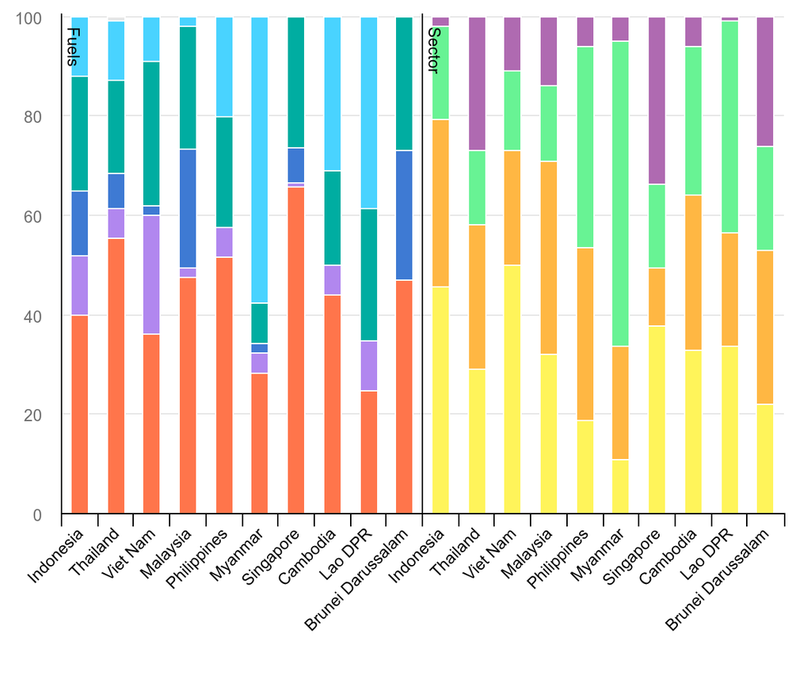

## Existing Chart: Strengths & Weaknesses

### Strengths

- Compact regional overview.
- Dual-panel layout links fuel and sector composition.
- Part-to-whole scale supports comparative reading.

### Weaknesses

- No on-chart legend, so colors cannot be decoded without source metadata.
- Two category systems (fuel and sector) raise cognitive load.
- Percentage-only values hide absolute energy scale differences.
- Mid-stack segment comparisons are hard.
- Heavy color dependence reduces accessibility.

## Critical Analysis - What Works

- **S1:** Compact regional overview across all ten ASEAN countries
- **S2:** Useful dual-panel structure linking fuel mix and end-use sector mix
- **S3:** 100% stacked format supports proportional comparison

**Key message:** the original chart is useful as a broad regional overview, but it has limitations for detailed comparison.

## Critical Analysis - Key Weaknesses

| Weakness | How it affects interpretation |
| --- | --- |
| W1-W2 | Two category systems increase mental switching and reduce segment-level comparability. |
| W3 | Percentage-only values hide total energy scale and may overstate small countries. |
| W4 | Color decoding dominates, which hurts accessibility and speed. |
| W5-W6 | Weak ordering and annotation make targeted country comparisons harder. |

## Proposed Improvements

| Weakness | Improvement |
| --- | --- |
| W1 | Clearer separation of fuel and sector panels |
| W2 | Horizontal layout or aligned comparison design |
| W3 | Data note explaining the percentage-only limitation |
| W4 | Colourblind-safe palette and cleaner legend |
| W5 | Selective annotations and callouts |
| W6 | Sort countries by a meaningful analytical metric |

## Redesign Direction

- Keep the original chart’s core purpose: compare energy patterns across ASEAN countries.
- Preserve both perspectives: fuel mix and end-use sector.
- Use aligned panels and cleaner labels so side-by-side comparison is easier.

## Redesign Direction

- Improve readability with stronger visual hierarchy and fewer interpretation steps.
- Use a more accessible colour palette and simpler legend and annotations.
- Add an explicit note that values are percentages, not absolute energy totals.

## Analysis Plan

- Summarise fuel and sector shares for each country and find dominant categories.
- Compare dominant fuel and dominant sector with 100% normalization checks.
- Combine fuel and sector comparison into an ascending vulnerability ranking to find energy-demand exposure.

## Reproducible Workflow

- Standardize the dataset into one clean table.
- Run checks for missing values, duplicates, invalid percentages, and outliers.
- Normalize country names, percentage types, and factor levels.

```r
country_levels <- c(
  "Brunei Darussalam", "Cambodia", "Indonesia", "Lao PDR",
  "Malaysia", "Myanmar", "Philippines", "Singapore", "Thailand", "Vietnam"
)

normalize_country_name <- function(country) {
  dplyr::recode(
    stringr::str_squish(country),
    "Lao DPR" = "Lao PDR",
    "Viet Nam" = "Vietnam",
    .default = stringr::str_squish(country)
  )
}

energy_data <- readr::read_csv(
  file.path("data", "energy_data.csv"),
  show_col_types = FALSE
) |>
  dplyr::mutate(
    Country = factor(normalize_country_name(Country), levels = country_levels),
    Percentage = as.numeric(Percentage),
    Dimension = factor(stringr::str_squish(Dimension), levels = c("Fuel", "Sector")),
    Category = factor(stringr::str_squish(Category))
  )
```

## Reproducible Workflow

- Reuse this dataset for both visualization and analysis.
- Recreate outputs using fixed commands: `quarto render`.
- Verify data chart accuracy and pipelines anomalies.

```r
required_cols <- c("Country", "Dimension", "Category", "Percentage")
stopifnot(all(required_cols %in% names(energy_data)))
stopifnot(all(!is.na(energy_data$Country)), all(!is.na(energy_data$Dimension)), all(!is.na(energy_data$Category)), all(!is.na(energy_data$Percentage)))
stopifnot(all(energy_data$Percentage >= 0), all(energy_data$Percentage <= 100))
stopifnot(nrow(energy_data |> dplyr::count(Country, Dimension, Category) |> dplyr::filter(n > 1)) == 0)

composition_check <- energy_data |>
  dplyr::group_by(Country, Dimension) |>
  dplyr::summarise(total_pct = sum(Percentage, na.rm = TRUE), .groups = "drop")

stopifnot(all(abs(composition_check$total_pct - 100) <= 1e-2))
sessionInfo()
```

## Final Data Visualization

- Compare fuel and sector shares side by side across countries.
- Keep country order fixed for direct pattern comparison.
- Use percentage scales so all charts are directly comparable.

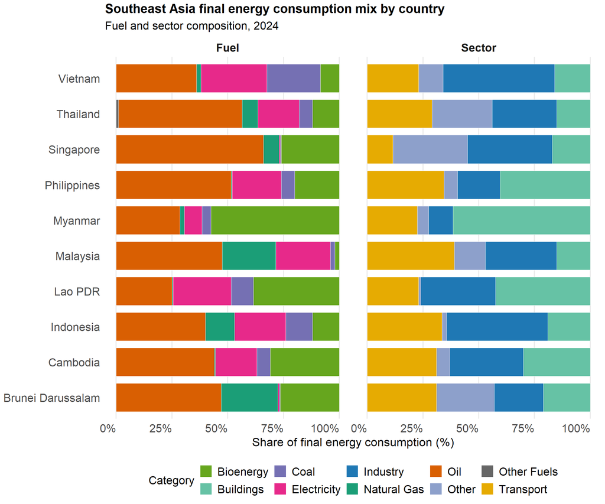

## Final Data Analysis

- Rank countries by fuel-sector vulnerability.
- Fill bar colours by dominant fuel
- Apply text above each bar for dominant sector.

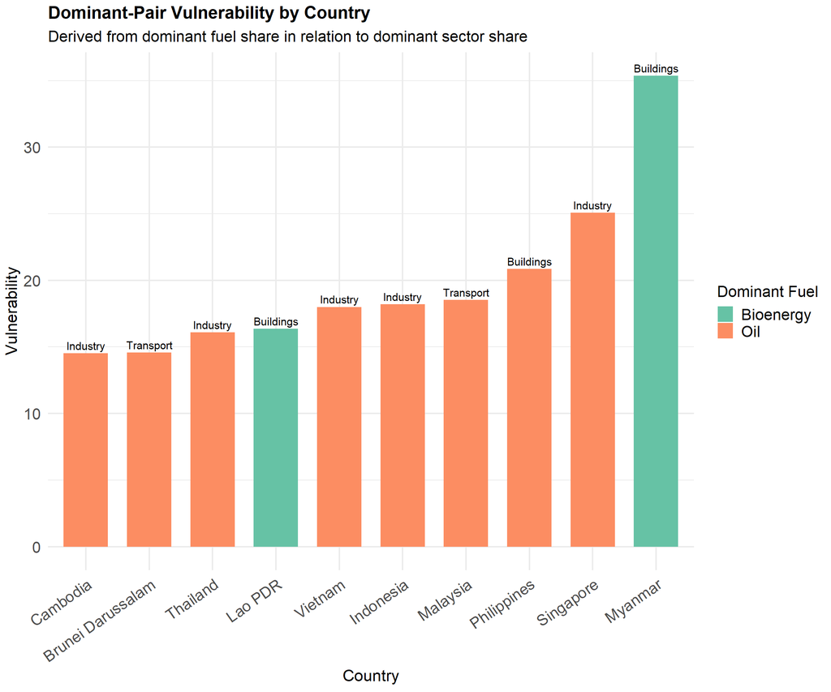